# statistics

*solution_03_central_limit_theorem/02_normal/07_x_from_leftarea_v5*

[video (using z-table)](https://vimeo.com/531935144)

[video (using app)](https://vimeo.com/531935582): the [app](http://18.191.167.248:3838/nprob/)

First, draw a sketch. We can label the $C$ axis by adding integer multiples of 100 to 420. We know to shade the left because low values of $C$ satisfy the condition $C<c$ (regardless of the exact value of $c$). We don’t know exactly where to place the boundary, but we know the left area is 0.17.

It is helpful to know the following approximations:

| $z$ | $P(Z<z)$ |
| --- | --- |
| -3 | 0.001 |
| -2 | 0.023 |
| -1 | 0.159 |
| 0 | 0.5 |
| 1 | 0.841 |
| 2 | 0.977 |
| 3 | 0.999 |

So, we know the $z$-score is between -1 and 0. Remember, $Z$ and $z$ always refer to the **standard** normal variable.

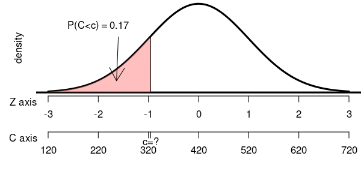

By using the $z$ table we can determine $z$ more precisely.

[output not shown]

Either -0.96 or -0.95 is a good estimation of $z$, and either value will lead you to an acceptable answer. Using other tools, a more accurate value can be found. I will show the work with a more accurate value.
$$z=-0.9542$$

We now convert the $z$ score into a $c$ score.
$$\begin{aligned}
c &= \mu+z\sigma \\
&= 420+(-0.9542)(100) \\
&= 324.6
\end{aligned}$$

We can also visualize this with a spinner.

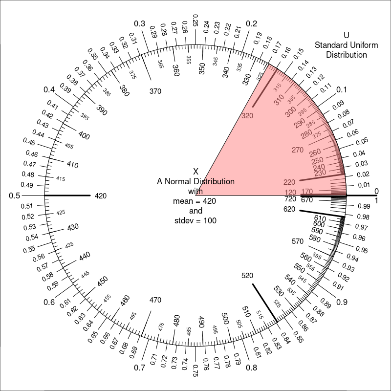

The tolerance for an acceptable answer was $\pm 10$ from 324.5834747. So, anything between 314.5834747 and 334.5834747 was accepted.

ANSWERS: 324.5834747  
TOLERANCES: 10